# Mortality Time Series with the CenSoc-Numident Dataset

Leslie Root (leslie.root@berkeley.edu)

2020-08-28

**Summary**: This vignette gives an overview of the CenSoc-Numident dataset. In the examples that follow, we use the Numident data in an *unlinked* format. Our goals for this vignette are:

```
1. To develop familiarity with the Numident death data, its possibilities and limitations;
2. To construct and visualize a descriptive analysis of seasonal death patterns using this data; and
3. To consider possible avenues for extending this analysis with a linked dataset.
```

The original R notebook (.Rmd file) for this vignette can be downloaded [here](https://github.com/lesliejroot/CenSoc).

Before getting started with the vignette, make sure to:

- [Download](https://censoc-download.demog.berkeley.edu/) the CenSoc Numident File (note: not the demo file! The file used here is currently called censoc_numident_v1.zip)
- Install packages if necessary:  
  -tidyverse  
  -knitr  
  -here  
  -viridis

# Getting started

Load packages and read in the data:

```r
## Library Packages
library(tidyverse)
library(knitr)
library(here)
library(viridis)

#edit this line to make sure it points to your downloaded dataset. I like to use the "here" package to make finding files easier, but if you prefer not to, you can remove it from this command. The file is large, so this might take a few seconds to run.
options(readr.show_progress = FALSE)
num <- read_csv(here("/censoc_numident_v1.csv"))

## what are our variables?
colnames(num)
```

```
##  [1] "HISTID"                "byear"                 "bmonth"
##  [4] "dyear"                 "dmonth"                "death_age"
##  [7] "sex"                   "race_first"            "race_first_cyear"
## [10] "race_first_cmonth"     "race_last"             "race_last_cyear"
## [13] "race_last_cmonth"      "bpl"                   "zip_residence"
## [16] "socstate"              "age_first_application" "weight"
```

We can see from the list of variable names that we have a pretty limited amount of information:  
- person ID (used to link to the 1940 Census)  
- birth and death dates (month and year)  
- age at death  
- sex  
- a few measures of race and date information on when they were collected  
- birthplace  
- residence at time of death (as a ZIP code)  
- state where the Social Security card was issued  
- age at first Social Security application  
- and a person-weight.

*Note that this is more information than the CenSoc-DMF data, which does not contain Social Security application covariates, and only includes men. (However, the DMF data has more years available.) For comparison of the various datasets currently available, be sure to visit [CenSoc](http://censoc.berkeley.edu).

Anything else we want to know about the people whose deaths are recorded in this dataset will have to come from linkage to the 1940 Census. For now, though, let's see what we can get out of the data we have here.

```r
table(num$death_age)
```

```
##
##     47     48     49     50     51     52     53     54     55     56     57
##     27    699   1718   3033   4648   7091  10489  14605  19522  25986  32195
##     58     59     60     61     62     63     64     65     66     67     68
##  40148  48789  60388  72899 109996 130914 153436 180615 195611 208274 219115
##     69     70     71     72     73     74     75     76     77     78     79
## 231426 243118 254964 266056 275551 280266 283916 284096 280353 276115 267358
##     80     81     82     83     84     85     86     87     88     89     90
## 259530 247181 233436 219060 201134 182838 163871 144741 126266 106831  88080
##     91     92     93     94     95     96     97     98     99    100    101
##  72039  59986  49889  41331  34733  28111  22213  17408  13087   9750   6985
##    102    103    104    105    106    107    108    109    110    111    112
##   4538   2995   1921   1125    698    390    214    116     54     27     16
##    113    114    115    116    118    120    121
##     10      5      5      1      1      2      1
```

Interesting - our death ages start at 47 and go up to 121. Why is that? Let's look by year of death:

```r
table(num$death_age,num$dyear)
```

```
##
##        1988  1989  1990  1991  1992  1993  1994  1995  1996  1997  1998  1999
##   47     27     0     0     0     0     0     0     0     0     0     0     0
##   48    661    38     0     0     0     0     0     0     0     0     0     0
##   49    971   717    30     0     0     0     0     0     0     0     0     0
##   50   1013  1118   856    46     0     0     0     0     0     0     0     0
##   51   1113  1145  1298  1039    53     0     0     0     0     0     0     0
##   52   1271  1288  1349  1558  1545    80     0     0     0     0     0     0
##   53   1467  1481  1407  1676  2283  2061   114     0     0     0     0     0
##   54   1564  1639  1639  1859  2425  2946  2413   120     0     0     0     0
##   55   1723  1765  1936  1948  2608  3246  3408  2763   125     0     0     0
##   56   1993  1933  2075  2313  2904  3556  3690  4200  3176   146     0     0
##   57   2131  2159  2166  2409  3217  3799  3884  4248  4602  3423   157     0
##   58   2438  2387  2451  2565  3430  4140  4351  4536  4880  5025  3765   180
##   59   2701  2846  2656  2995  3710  4384  4717  4993  5046  5182  5182  4173
```

[output cut: 135 more lines]

Aha! It's because our data runs from 1988 to 2005 - the years with the best Social Security death coverage. And we only observe people who were alive in 1940 - people who can potentially be linked to the 1940 Census.

# Mortality time series by sex

Let's construct a straightforward count of deaths by month/year, broken down by sex. First we need to adjust using the person weights provided. These weights were calculated based on [Human Mortality Database](http://mortality.org) data - for more details, see the [CenSoc Methods Protocol (pdf)](https://censoc.berkeley.edu/wp-content/uploads/2020/04/censoc_methods_protocol.pdf) - and it's important to use them, as some of them are quite large!

*Note - I like to use the pipe operator [%>%] to make my code briefer and more organized - if you're not familiar with it, check out [this tutorial](https://www.datacamp.com/community/tutorials/pipe-r-tutorial) for more information.

```r
#a lot of people's weights are NA - they should be assigned a weight of 1
num$weight <- ifelse(is.na(num$weight),1,num$weight)

deaths <- num %>%
  ##let's look at people 65 and older, because they are observed in every year of the data
  filter(death_age >= 65) %>%
  #"mutate" sex to something more intuitive
  mutate(sex = ifelse(sex==1, "M", "F")) %>%
  #to plot a timeseries, let's make the dates into an index. January 1988 becomes 1988.0, and each month adds 1/12 (~0.083) to that number.
  #here we see that we can use "mutate" not only to change the coding of extant variables, but to create a new variable, "index":
  mutate(index = (dyear + (dmonth/12-1/12))) %>%
  #might as well keep year and month data, as well as index (it doesn't add any information, but later we'll use the dyear column again). group_by    helps us transform our dataframe from microdata into summary counts:
  group_by(dyear,dmonth,index,sex) %>%
  #final step - make a new variable that counts the number of deaths by the variables specified in the above step^
  summarise(deaths=sum(weight))
head(deaths)
```

| dyear | dmonth | index | sex | deaths |
| --- | --- | --- | --- | --- |
| 1988 | 1 | 1988.000 | F | 60124.33 |
| 1988 | 1 | 1988.000 | M | 57484.78 |
| 1988 | 2 | 1988.083 | F | 65906.84 |
| 1988 | 2 | 1988.083 | M | 63103.75 |
| 1988 | 3 | 1988.167 | F | 69524.33 |
| 1988 | 3 | 1988.167 | M | 66672.70 |

Great, our dataframe has now been rearranged to give us monthly death counts by sex. Let's plot these deaths:

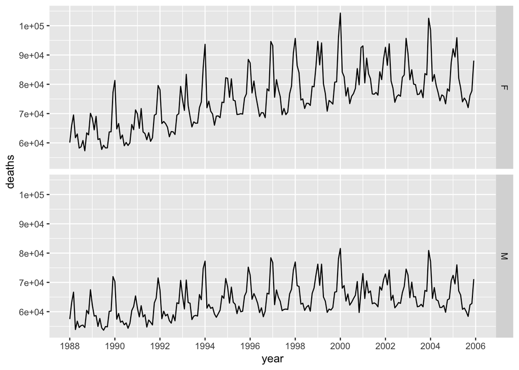

```r
deaths %>%
  ggplot(aes(index, deaths)) +
  geom_line() +
  ylab("deaths")+
  xlab("year")+
  scale_x_continuous(breaks = seq(1988, 2006, 2),lim=c(1988,2006))+
  facet_grid(rows=vars(sex))
```

These plots show that deaths oscillate throughout the year, and it looks like they do it in somewhat regular fashion. Let's investigate further.

## Isolating seasonal variation

We can divide the observed deaths each month by the expected deaths to get a standardized version of the seasonal variation - we will no longer see the rising time trend, only the fluctuations throughout each year. Monthly expected deaths, assuming flat mortality throughout the year, are defined as:

$$monthly\_expected\_deaths = \frac{yearly\_deaths}{days\_in\_year} * days\_in\_month$$

The simplest way to do this would be to just divide the yearly deaths by 12, but since no month is technically 1/12 of the year, this more precise calculation is more accurate. As this code shows, it accounts for both variation in length of month and for 366-day leap years. You can never be too precise!

I then calculated "standardized deaths" as a percentage deviation from the monthly expectation, but there are certainly other substantively identical ways one could construct this variable, if this construction doesn't seem intuitive to you:

$$standardized\_deaths = (100 * \frac{monthly\_observed\_deaths}{monthly\_expected\_deaths})-100$$

```r
yrdeaths <- num %>%
  filter(death_age >= 65) %>%
  mutate(sex = ifelse(sex==1, "M", "F")) %>%
  group_by(dyear,sex) %>%
  summarize(deaths=sum(weight)) %>%
  mutate(avgdeaths1 = (deaths/365)*31) %>%
  mutate(avgdeaths2 = (deaths/365)*30) %>%
  mutate(avgdeaths3 = (deaths/365)*28) %>%
  mutate(avgdeaths4 = (deaths/366)*31) %>%
  mutate(avgdeaths5 = (deaths/366)*30) %>%
  mutate(avgdeaths6 = (deaths/366)*29)
deaths <- merge(deaths,yrdeaths,by=c("dyear","sex"))

deaths <- deaths %>%
  select(-deaths.y) %>%
  rename(deaths=deaths.x) %>%
  mutate(stdeaths = ifelse(dmonth %in% c(1,3,5,7,8,10,12),100*deaths/avgdeaths1-100,NA)) %>%
  mutate(stdeaths = ifelse(dmonth %in% c(4,6,9,11),100*deaths/avgdeaths2-100,stdeaths)) %>%
  mutate(stdeaths = ifelse(dmonth == 2, 100*deaths/avgdeaths3-100,stdeaths)) %>%
  mutate(stdeaths = ifelse(dmonth %in% c(1,3,5,7,8,10,12) & dyear %in% c(1988,1992,1996,2000,2004),100*deaths/avgdeaths4-100,stdeaths)) %>%
  mutate(stdeaths = ifelse(dmonth %in% c(4,6,9,11) & dyear %in% c(1988,1992,1996,2000,2004),100*deaths/avgdeaths5-100,stdeaths)) %>%
  mutate(stdeaths = ifelse(dmonth == 2 & dyear %in% c(1988,1992,1996,2000,2004),100*deaths/avgdeaths6-100,stdeaths))
```

Now to plot the standardized deaths:

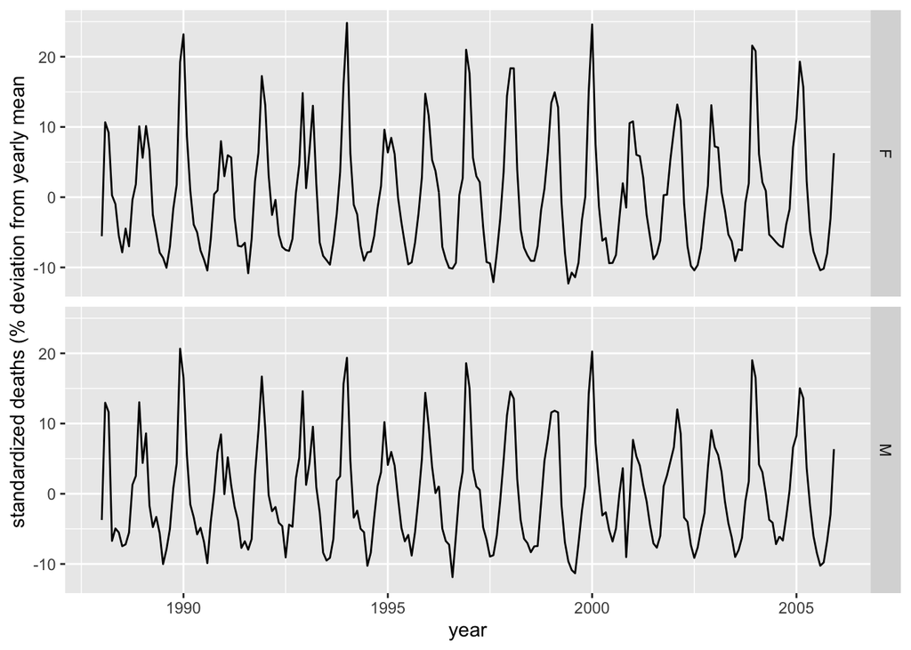

```r
deaths %>%
  ggplot(aes(index, stdeaths)) +
  geom_line()+
  ylab("standardized deaths (% deviation from yearly mean")+
  xlab("year")+
  facet_grid(rows=vars(sex))
```

Overlapping the two sexes makes it clearer that women experience slightly more seasonal variation than men:

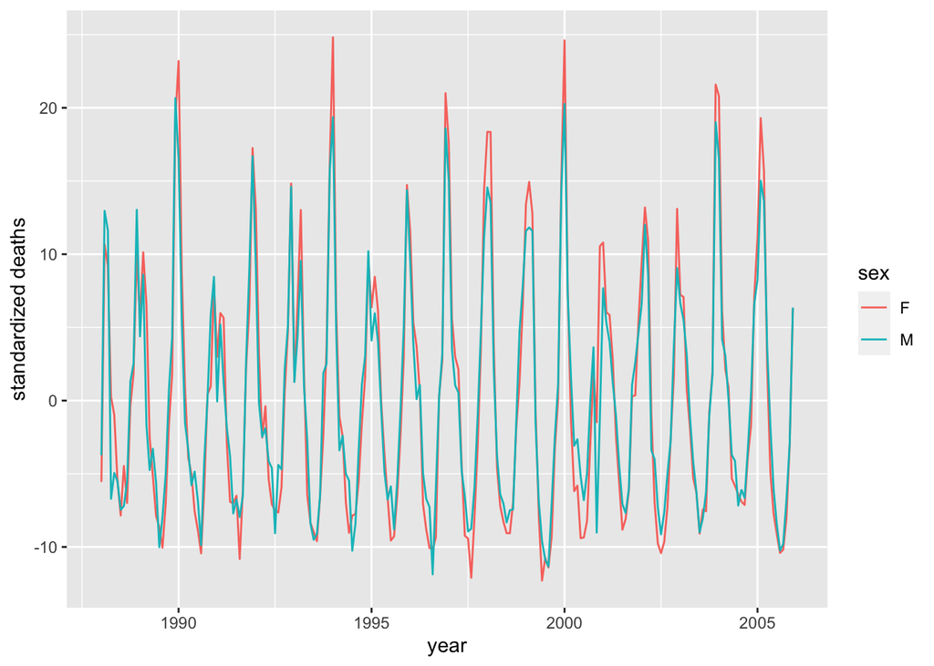

```r
deaths %>%
  ggplot(aes(index, stdeaths,color=sex)) +
  geom_line()+
  ylab("standardized deaths")+
  xlab("year")
```

This is in line with previous research that finds that women have higher mortality rates for influenza, a significant driver of seasonal mortality variation.

# Seasonal death heatmaps

We can also plot the seasonal death patterns as a heatmap! First, death counts by month and year:

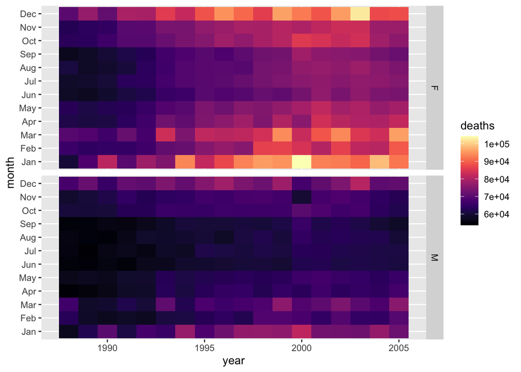

```r
deaths$dmonth_text <- as.factor(deaths$dmonth)

levels(deaths$dmonth_text) <- c("Jan","Feb","Mar","Apr","May","Jun","Jul","Aug","Sep","Oct","Nov","Dec")

ggplot(deaths, aes(dyear, dmonth_text, fill= deaths)) +
  geom_tile() +
  scale_fill_viridis(option = "magma")+
  ylab("month")+
  xlab("year")+
  facet_grid(rows=vars(sex))
```

This heatmap, like the line graph above, clearly shows how much more female deaths rose over this time period than male deaths. Now let's look at standardized deaths:

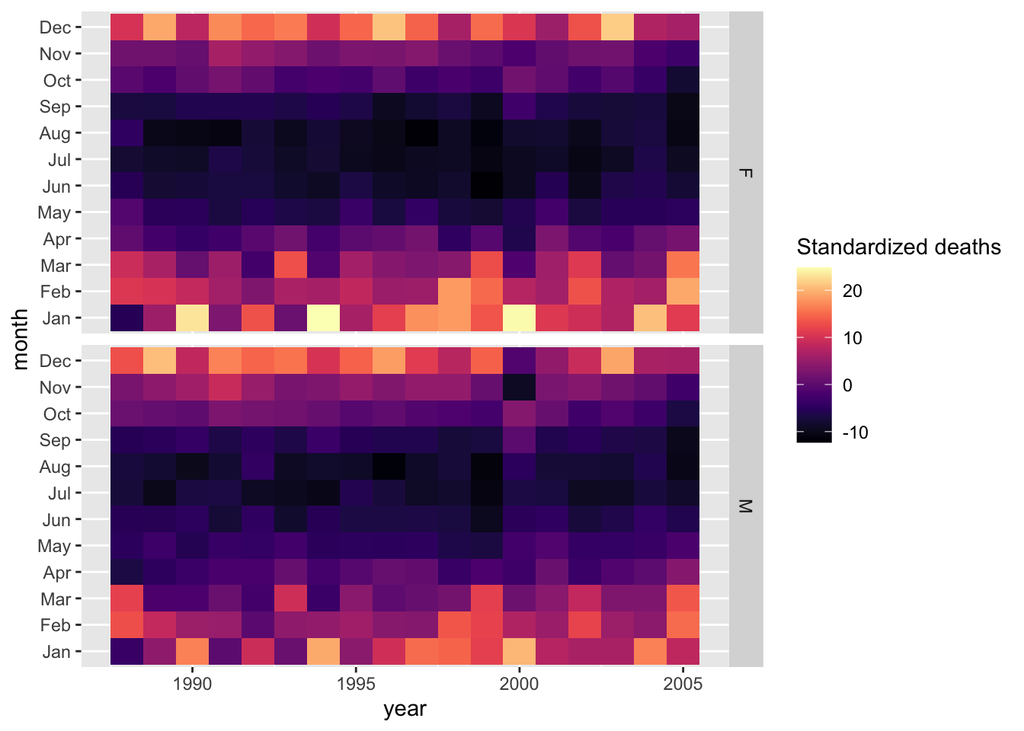

```r
ggplot(deaths, aes(dyear, dmonth_text, fill= stdeaths)) +
  geom_tile() +
  scale_fill_viridis(option = "magma")+
  ylab("month")+
  xlab("year")+
  scale_color_discrete(name="standardized deaths")+
  labs(fill = "Standardized deaths")+
  facet_grid(rows=vars(sex))
```

These heatmaps help us see clearly that June through September consistently have below-average deaths, while the month with the most excess death is generally between December and March, but seems to vary among those winter months a bit more randomly.

# Describing variation by age at death

In addition to comparing by sex, we can see, for example, whether women who die at younger-old ages (65-74), middle-old ages (75-84), or oldest-old ages (85+) experience the most seasonal variation in deaths. First we need to construct a factor variable for age with three levels, and then redo a good bit of the code above, to generate death counts by age group.

```r
deaths2 <- num %>%
  filter(death_age >= 65) %>%
  #convert age into a factor with three levels: young, mid, and old
  mutate(age_index = ifelse(death_age<75,"young",NA))%>%
  mutate(age_index = ifelse(death_age>=75,"mid",age_index))%>%
  mutate(age_index = ifelse(death_age>=85,"old",age_index)) %>%
  mutate(sex = ifelse(sex==1, "M", "F")) %>%
  filter(sex == "F") %>%
  mutate(index = (dyear + (dmonth/12-1/12))) %>%
  group_by(dyear,dmonth,index,age_index) %>%
  summarise(deaths=sum(weight))
#put the factor's levels in the proper order
deaths2$age_index <- factor(deaths2$age_index,levels=c("young","mid","old"))

head(deaths2)
```

| dyear | dmonth | index | age_index | deaths |
| --- | --- | --- | --- | --- |
| 1988 | 1 | 1988.000 | mid | 25035.85 |
| 1988 | 1 | 1988.000 | old | 19308.75 |
| 1988 | 1 | 1988.000 | young | 15779.73 |
| 1988 | 2 | 1988.083 | mid | 27335.04 |
| 1988 | 2 | 1988.083 | old | 21696.70 |
| 1988 | 2 | 1988.083 | young | 16875.10 |

From a basic plot of the time trend in deaths by age group, we can already see that the oldest-old have the most growth in numbers of death, as well as the most seasonal variation.

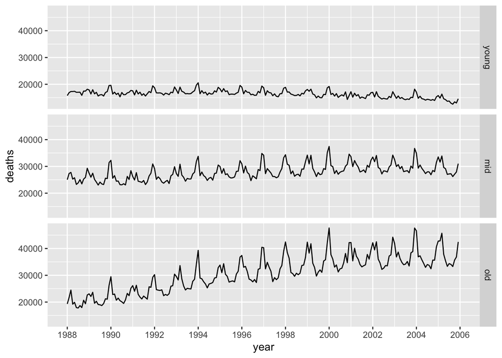

```r
deaths2 %>%
  ggplot(aes(index, deaths)) +
  geom_line() +
  ylab("deaths")+
  xlab("year")+
  scale_x_continuous(breaks = seq(1988, 2006, 2),lim=c(1988,2006))+
  facet_grid(rows=vars(age_index))
```

Constructing standardized deaths again:

```r
yrdeaths2 <- num %>%
  filter(death_age >= 65) %>%
  mutate(age_index = ifelse(death_age<75,"young",NA))%>%
  mutate(age_index = ifelse(death_age>=75,"mid",age_index))%>%
  mutate(age_index = ifelse(death_age>=85,"old",age_index)) %>%
  mutate(sex = ifelse(sex==1, "M", "F")) %>%
  filter(sex == "F") %>%
  group_by(dyear,age_index) %>%
  summarize(deaths=sum(weight)) %>%
  mutate(avgdeaths1 = (deaths/365)*31) %>%
  mutate(avgdeaths2 = (deaths/365)*30) %>%
  mutate(avgdeaths3 = (deaths/365)*28) %>%
  mutate(avgdeaths4 = (deaths/366)*31) %>%
  mutate(avgdeaths5 = (deaths/366)*30) %>%
  mutate(avgdeaths6 = (deaths/366)*29)
deaths2 <- merge(deaths2,yrdeaths2,by=c("dyear","age_index"))

deaths2 <- deaths2 %>%
  select(-deaths.y) %>%
  rename(deaths=deaths.x) %>%
  mutate(stdeaths = ifelse(dmonth %in% c(1,3,5,7,8,10,12),100*deaths/avgdeaths1-100,NA)) %>%
  mutate(stdeaths = ifelse(dmonth %in% c(4,6,9,11),100*deaths/avgdeaths2-100,stdeaths)) %>%
  mutate(stdeaths = ifelse(dmonth == 2, 100*deaths/avgdeaths3-100,stdeaths)) %>%
  mutate(stdeaths = ifelse(dmonth %in% c(1,3,5,7,8,10,12) & dyear %in% c(1988,1992,1996,2000,2004),100*deaths/avgdeaths4-100,stdeaths)) %>%
  mutate(stdeaths = ifelse(dmonth %in% c(4,6,9,11) & dyear %in% c(1988,1992,1996,2000,2004),100*deaths/avgdeaths5-100,stdeaths)) %>%
  mutate(stdeaths = ifelse(dmonth == 2 & dyear %in% c(1988,1992,1996,2000,2004),100*deaths/avgdeaths6-100,stdeaths))
```

Isolating and graphing the seasonal mortality variation, we can confirm that the youngest-old experience the least seasonal variation, and the oldest-old the most. We might hypothesize that this is attributable to differentials in influenza mortality by age.

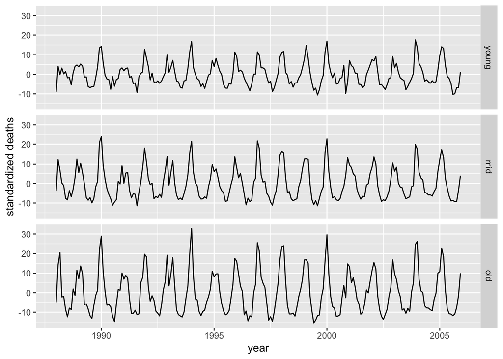

```r
deaths2 %>%
  ggplot(aes(index, stdeaths)) +
  geom_line()+
  ylab("standardized deaths")+
  xlab("year")+
  facet_grid(rows=vars(age_index))
```

# Seasonal death heatmaps by age group

Repeating our heatmaps, we can see that our monthly count of deaths is perhaps not best visualized this way, since the counts are so different for the different age groups.

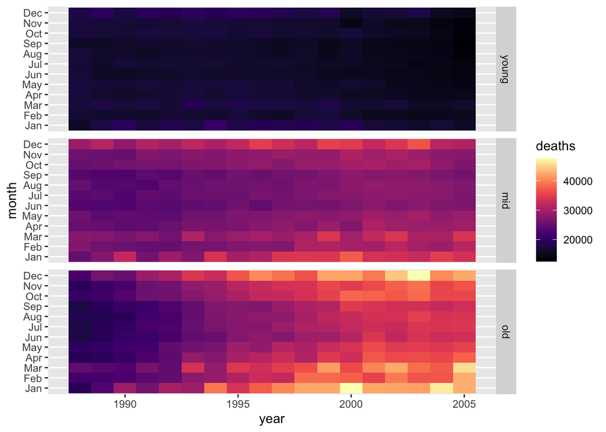

```r
deaths2$dmonth_text <- as.factor(deaths2$dmonth)

levels(deaths2$dmonth_text) <- c("Jan","Feb","Mar","Apr","May","Jun","Jul","Aug","Sep","Oct","Nov","Dec")

ggplot(deaths2, aes(dyear, dmonth_text, fill= deaths)) +
  geom_tile() +
  scale_fill_viridis(option = "magma")+
  ylab("month")+
  xlab("year")+
  facet_grid(rows=vars(age_index))
```

The heatmap of standardized deaths is a bit more useful - the gradient in extent of color variation between the three graphs is very clear.

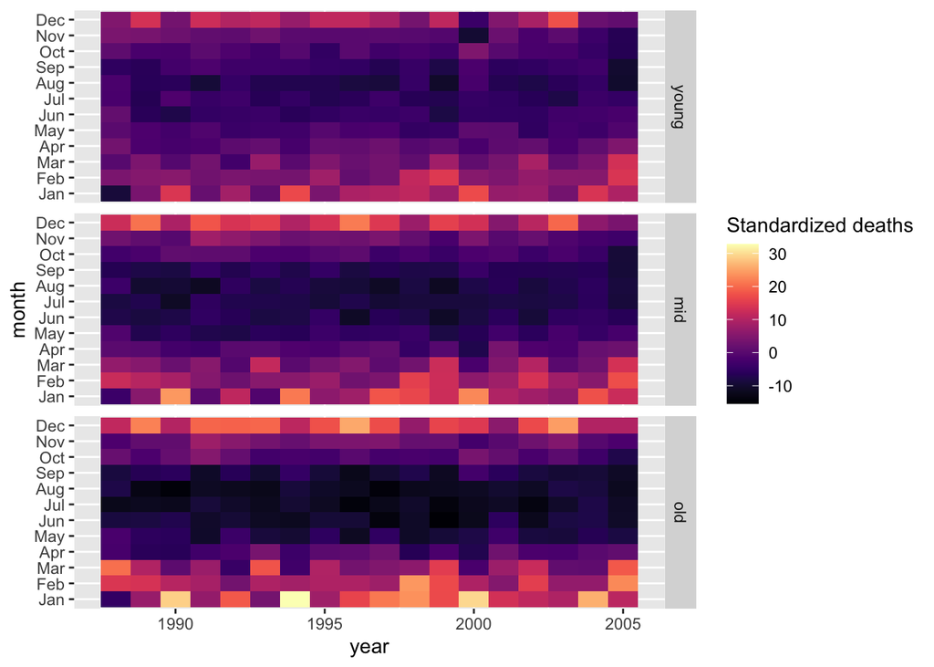

```r
ggplot(deaths2, aes(dyear, dmonth_text, fill= stdeaths)) +
  geom_tile() +
  scale_fill_viridis(option = "magma")+
  ylab("month")+
  xlab("year")+
  scale_color_discrete(name="standardized deaths")+
  labs(fill = "Standardized deaths")+
  facet_grid(rows=vars(age_index))
```

# Conclusion

However, this exercise on its own probably does not add much to our knowledge of seasonal mortality trends, which are heavily driven by influenza and pneumonia mortality and are thus pretty well-studied using datasets that include cause-of-death data. The potential added value from this data is in the many individual-level covariates available to us in the 1940 census. A future vignette will explore how to extend this analysis beyond the descriptive, by linking the full Numident data to the 1940 census.

# Epilogue

Although this vignette focused on seasonal variation, we can also use the yearly deaths data we generated to isolate the time trend, without the seasonal variation:

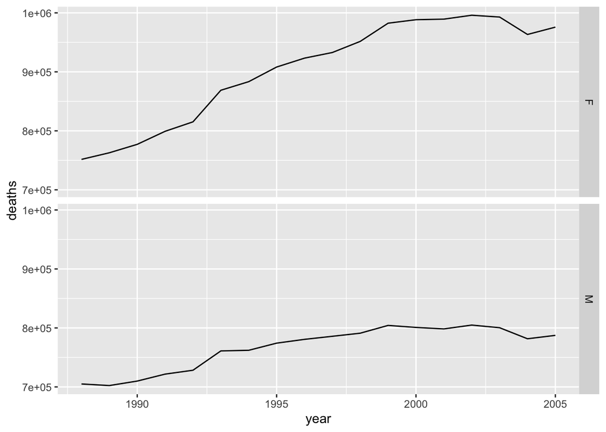

```r
yrdeaths %>%
  ggplot(aes(dyear, deaths)) +
  geom_line()+
  ylab("deaths")+
  xlab("year")+
  facet_grid(rows=vars(sex))
```

Wow! Looks like female deaths rose a lot more than male deaths during this period. Remember that these are raw counts, not rates, so changes in the population size and structure will have a large effect. To be on the safe side, let's compare this data to HMD data.

Data can be downloaded by creating a free account at [the HMD](https://www.mortality.org).

```r
hmd <- read.table(here("/Deaths_1x1.txt"),header=T,skip=2) %>%
  filter(Year %in% c(1988:2005)) %>%
  mutate(Age =ifelse(Age=="110+",110,Age)) %>%
  mutate(Age = as.numeric(as.character(Age))) %>%
  rename(dyear=Year) %>%
  filter(Age >= 65) %>%
  gather(sex,deaths,c("Female","Male","Total")) %>%
  filter(sex %in% c("Female","Male")) %>%
  mutate(sex = ifelse(sex=="Female","F","M")) %>%
  group_by(dyear,sex) %>%
  summarize(deaths=sum(deaths))
```

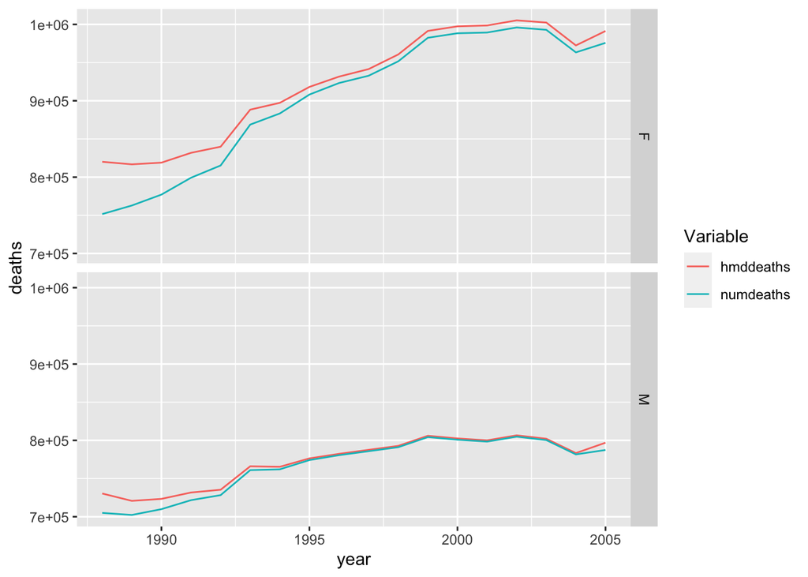

```r
yrdeaths <- merge(yrdeaths,hmd,by=c("dyear","sex")) %>%
  rename(numdeaths=deaths.x) %>%
  rename(hmddeaths=deaths.y) %>%
  gather(Variable,Value,c("numdeaths","hmddeaths"))


yrdeaths %>%
  ggplot(aes(dyear, Value,color=Variable)) +
  geom_line()+
  ylab("deaths")+
  xlab("year")+
  facet_grid(rows=vars(sex))
```

It looks like the Numident data varies quite a bit from the HMD data in the first few years, especially for women, but overall, the trend looks similar, and our observation that female deaths rose a lot more than did male deaths is borne out by this check.